# Kansas Voter Registration File - 2025-05-02

Earl F Glynn

2025-05-05

Script to perform quality checks and to produce frequency counts of fields in the Kansas voter registration file.

**History**

- Convert very old R script to markdown and tidyverse | 2019-01-26

**Output Files**

**State**

- `Kansas-Fixed.txt` - fix tab problem, header consistency
- `Kansas-Updated.txt` - add additional useful variables for analysis
- `Kansas-Counts-Age-yyyy-mm-dd.xlsx`
- `Kansas-Counts-State-yyyy-mm-dd.xlsx`
- `Kansas-Crosstab-BirthYear-by-BirthMonth-yyyy-mm-dd.xlsx`
- `Kansas-Crosstab-RegisterYear-by-RegisterMonth-yyyy-mm-dd.xlsx`
- `Kansas-Registrations-By-Year-and-Month-yyyy-mm-dd.svg`
- `Kansas-Election-Code-Summary-yyyy-mm-dd.xlsx`
- `Kansas-Explore-Name-Duplicates-yyyy-mm-dd.xlsx`
- `Kansas-Households-Address-to-Explore-for-Many-Voters-yyyy-mm-dd.xlsx`
- `Kansas-Households-Mail-to-Explore-for-Many-Voters-yyyy-mm-dd.xlsx`

**County**

- `Kansas-Counts-County-yyyy-mm-dd.xlsx`
- `Kansas-County-Voter-Election-Code-Summary-yyyy-mm-dd.xlsx`

**Precinct**

- `Kansas-Counts-Precinct-yyyy-mm-dd.xlsx`

**Voter**

- `Kansas-Election-Codes-by-Voter-yyyy-mm-dd.txt`
- `Kansas-Explore-Name-Duplicates-yyyy-mm-dd.xlsx`
- `Kansas-Voters-Missing-District-Info-yyyy-mm-dd.xlsx`

**Election Code**

- `Kansas-Election-Code-Summary-yyyy-mm-dd.xlsx`

**Data Fields**

- `Kansas-Field-Length-Summary-yyyy-mm-dd.xlsx`
- `Counts` folder with CSV file of frequency counts for each of ~90 fields

# 1 Backstage

## 1.1

## 1.2 Constants

```r
EXCEL_LIMIT <- 2^20
```

Use 5-year census intervals (except for interval 18-19)

```r
ageBreaks <- 5 * 3:17
ageBreaks[1] <- 18
```

[1] 18 20 25 30 35 40 45 50 55 60 65 70 75 80 85

```r
ageIntervals <-
  c(paste(ageBreaks[-length(ageBreaks)], ageBreaks[-1]-1, sep = "-"),
    paste0(ageBreaks[length(ageBreaks)], "+"))
ageIntervals[1] <- "18-19"
```

[1] “18-19” “20-24” “25-29” “30-34” “35-39” “40-44” “45-49” “50-54” “55-59” “60-64” [11] “65-69” “70-74” “75-79” “80-84” “85+”

## 1.3 Packages

```r
library(tidyverse)
```

```r
library(writexl)
library(kableExtra)
```

```r
library(lubridate)   # date/time functions
library(gplots)      # heatmap.2
```

```r
library(scales)      # comma
```

## 1.4 Helper Function

```r
Show <- function(data, caption="", bigMark="",
                 height = NULL, width = NULL, ...)
{
  data                                       |>
  kable("html", caption=caption,
        format.args=list(big.mark=bigMark))  |>
  kable_styling(bootstrap_options=c("striped", "bordered", "condensed"),
                position="left",
                full_width=FALSE, ...)       |>
  scroll_box(height = height, width = width)
}
```

# 2 Character Quality Check

Check for unusual characters using `CharCount` utility from [github](https://github.com/EarlGlynn/CharacterCount). This shows the count of the 256 possible 8-bit bytes in the file. Look for changes from recent files.

The `CharCount` table will confirm whether the field separator is a tab (x09) vs a comma (x2C), and identify possible problem characters

Screen shot of running CharCount is saved to file `CharCount.png` for inclusion here.

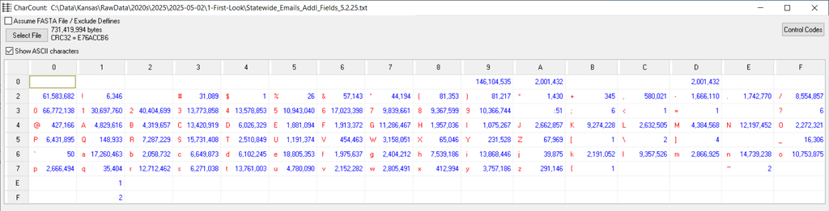

The number of problem characters is now fairly low compared to past years.

Problems can include x’E1’ and x’F1’. Failure to fix these characters can cause problems.

See use of `iconv` below.

# 3 Raw data file

## 3.1 Parameters

```r
cat("Raw Data: ",       params$RAW_VOTER_FILE,
    "\nFixed File: ",   params$FIXED_VOTER_FILE,
    "\nUpdated File: ", params$UPDATED_VOTER_FILE,
    "\nElection Date (for age computations): ", params$ELECTION_DATE, "\n")
```

```
Raw Data:  Statewide_Emails_Addl_Fields_5.2.25.txt
Fixed File:  Kansas-Fixed.txt
Updated File:  Kansas-Updated.txt
Election Date (for age computations):  2025-08-05
```

The Kansas statewide file has had problems in the parsability of records for various reasons. So, let’s check for such problems.

## 3.2 Fix problems in file programmatically

Records with too many tabs are from Geary County since 2006.

Fix encoding issue, since text is not interpreted as a valid string because it contains non-ASCII characters.

```r
rawLines <-
  read_lines(params$RAW_VOTER_FILE)       |>
  iconv(from = "ISO-8859-1", to = "UTF-8")

length(rawLines)
```

```
[1] 2001432
```

### 3.2.1 Make header like rest of data records.

Kansas-specific problem since 2006!

Add tab to end of header row to make it like other data lines with final tab.

Maybe someday the Kansas Secretary of State’s Office could fix this anomaly?

This makes the header row tab terminated, like the rest of the data.

BUT, there will be a blank last column that needs to be deleted.

```r
rawLines[1] <- paste(rawLines[1], "\t", sep="")
```

### 3.2.2 Fix problem Geary County record

[Problem started in 2006!!]

See `C:\Data\Kansas\RawData\2020s\2023\2023-02-13\Geary-County-Parse-Problem.docx`

```r
verify1 <- grep("778 TC CO\t\t5302 ASHBY AVE\t", rawLines)
length(verify1)
```

```
[1] 0
```

This Geary County problem was finally resolved in May 2025. Continue making this check until 2026.

### 3.2.3 Create `Fixed` data

```r
write_lines(rawLines, params$FIXED_VOTER_FILE)
```

## 3.3 Delimiter Check

- With fixes above, all records should parse consistently. Let’s check.
- Without `comment.char` override, records with # characters are problems.
- Without `quote` override, records with apostrophes or quotation marks are problems.

```r
counts <- tibble(fieldCounts = count.fields(params$FIXED_VOTER_FILE,
                                            sep="\t",
                                            comment.char="",
                                            quote=""))
```

```r
freqCounts <-
  counts                                |>
  group_by(fieldCounts)                 |>
  summarize(n = n(), .groups = "drop")  |>
  ungroup()

freqCounts |>
    Show(bigMark = ",")
```

| fieldCounts | n |
| --- | --- |
| 74 | 2,001,432 |

All records should have the same number of fields.

## 3.4 Read fixed file

```r
voters <- read_delim(params$FIXED_VOTER_FILE, "\t",
                     quote = "",
                     comment = "",
                     na = character(),  # some people might have names of "NA"
                     col_types = cols(.default = "c"),
                     progress = FALSE)
```

```r
dim(voters)
```

```
[1] 2001431      74
```

There is an extra column R created because of the tab at the end of each line. (Tabs are “separators” not “terminators”.)

Verify final unwanted column has no info.

```r
table(voters[,ncol(voters)], useNA="ifany")
```

```
...74

2001431
```

Get rid of unwanted column

```r
voters <- voters[,-ncol(voters)]
```

```r
glimpse(voters)
```

```
Rows: 2,001,431
Columns: 73
$ db_logid                       <chr> "Allen", "Allen", "Allen", "Allen", "Al…
$ cde_registrant_status          <chr> "A   ", "I   ", "A   ", "A   ", "I   ",…
$ cde_name_title                 <chr> "", "", "", "", "", "", "", "", "", "",…
$ . . . edited

$ cde_gender                     <chr> "M   ", "M   ", "F   ", "F   ", "F   ",…
. . . edited

$ text_res_city                  <chr> "Iola", "Iola", "Iola", "Iola", "Iola",…
$ cde_res_state                  <chr> "KS", "KS", "KS", "KS", "KS", "KS", "KS…
$ text_res_zip5                  <chr> "66749 ", "66749 ", "66749 ", "66749 ",…
$ . . . edited

```

[output cut: 41 more lines]

### 3.4.1 Parties

Verify current political parties (new ones added in 2024):

Recode missing party to `Unaffiliated`

```r
table(voters$desc_party, useNA = "ifany")
```

```
      Democratic      Libertarian No Labels Kansas       Republican
          501075            23892             4951           902052
    Unaffiliated    United Kansas
          568687              774
```

### 3.4.2 Genders

Recode missing gender to `U`in cleanup below.

```r
table(voters$cde_gender, useNA = "ifany")
```

```
           F       M       U
   3568 1038758  950244    8861
```

# 4 Cleanup / Fixups / Add new variables

## 4.1 Osage County Congressional District Fix

Assign Osage County CG0002 Congressional District

[Resource to confirm Osage is in 2nd Congressional District](https://www2.census.gov/geo/maps/cong_dist/cd117/cd_based/ST20/CD117_KS02.pdf)

```r
table(voters$district_cg, useNA = "ifany")
```

```
       CG0001 CG0002 CG0003 CG0004
   295 479550 488371 544794 488421
```

Fix this problem below.

```r
cgProblem <-
  voters |>
  filter(district_cg == " ")

nrow(cgProblem)
```

```
[1] 295
```

```r
table(cgProblem$db_logid, useNA = "ifany")
```

```
Osage
  295
```

```r
target <- which(voters$district_cg == " ")
voters$district_cg[target] <- "CG0002"
length(target)
```

```
[1] 295
```

```r
table(voters$district_cg, useNA = "ifany")
```

```
CG0001 CG0002 CG0003 CG0004
479550 488666 544794 488421
```

## 4.2 Wrong State Senate Districts

- Scott County KS0033 → KS0039
- Wilson County KS0014 → KS0012

```r
voters |>
  filter(db_logid %in% c("Scott", "Wilson")) |>
  group_by(db_logid)   |>
  count(district_ks )  |>
  Show()
```

| db_logid | district_ks | n |
| --- | --- | --- |
| Scott | KS0033 | 3511 |
| Wilson | KS0014 | 5034 |

### 4.2.1 Scott County

[Senate District 33](https://kslegislature.gov/li/s/pdf/district_maps/district_map_s_033.pdf) does not contain Scott County.

[Senate District 39](https://kslegislature.gov/li/s/pdf/district_maps/district_map_s_039.pdf) map shows it contains Scott County

```r
target <- which(voters$db_logid == "Scott")
voters$district_ks[target] <- "KS0039"
length(target)
```

```
[1] 3511
```

## 4.3 Wilson County

[Senate District 14](https://kslegislature.gov/li/s/pdf/district_maps/district_map_s_014.pdf) does not contain Wilson County.

[Senate District 12](https://kslegislature.gov/li/s/pdf/district_maps/district_map_s_012.pdf) map shows it contains Wilson County]

```r
target <- which(voters$db_logid == "Wilson")
voters$district_ks[target] <- "KS0012"
length(target)
```

```
[1] 5034
```

Verify fix

```r
voters |>
  filter(db_logid %in% c("Scott", "Wilson")) |>
  group_by(db_logid)   |>
  count(district_ks )  |>
  Show()
```

| db_logid | district_ks | n |
| --- | --- | --- |
| Scott | KS0039 | 3511 |
| Wilson | KS0012 | 5034 |

## 4.4 Other cleanup

Get rid of leading/trailing blanks in many fields. Should be fixed in state file.

```r
votersModified <-
  voters                              |>
  rename(County = db_logid)           |>   # `County` should never have been `db_logid`
  mutate(
          cde_registrant_status       = str_trim(cde_registrant_status) |>
                                        str_to_upper(),  # Lower case happened once

          # many fields have leading blanks to trim -- should probably trim all fields
          cde_name_title              = str_trim(cde_name_title),
          text_name_first             = str_trim(text_name_first),
          text_name_middle            = str_trim(text_name_middle),
          text_name_last              = str_trim(text_name_last),
          cde_name_suffix             = str_trim(cde_name_suffix),

          registrant_text_email       = str_trim(registrant_text_email),

          text_res_address_nbr        = str_trim(text_res_address_nbr),
          text_res_address_nbr_suffix = str_trim(text_res_address_nbr_suffix),
          cde_street_dir_prefix       = str_trim(cde_street_dir_prefix),
          text_street_name,
          cde_street_type             = str_trim(cde_street_type),
          cde_street_dir_suffix       = str_trim(cde_street_dir_suffix),
          cde_res_unit_type           = str_trim(cde_res_unit_type),
          text_res_unit_nbr           = str_trim(text_res_unit_nbr),
          text_res_zip5               = str_trim(text_res_zip5),
          text_res_zip4               = str_trim(text_res_zip4),

          text_mail_address1          = str_squish(text_mail_address1),  # also remove extra internal spaces
          text_mail_address2          = str_squish(text_mail_address2),
          text_mail_address3          = str_squish(text_mail_address3),
          text_mail_address4          = str_squish(text_mail_address4),
          text_mail_city              = str_trim(text_mail_city),
          cde_mail_state              = str_trim(cde_mail_state),
          text_mail_zip5              = str_trim(text_mail_zip5),
          text_mail_zip4              = str_trim(text_mail_zip4),

          text_res_carrier_rte        = str_trim(text_res_carrier_rte),
          text_mail_carrier_rte       = str_trim(text_mail_carrier_rte),

          text_phone_exchange         = str_trim(text_phone_exchange),
          text_phone_last_four        = str_trim(text_phone_last_four),

          text_election_code_1        = str_trim(text_election_code_1),
          text_election_code_2        = str_trim(text_election_code_2),
          text_election_code_3        = str_trim(text_election_code_3),
          text_election_code_4        = str_trim(text_election_code_4),
          text_election_code_5        = str_trim(text_election_code_5),
          text_election_code_6        = str_trim(text_election_code_6),
          text_election_code_7        = str_trim(text_election_code_7),
          text_election_code_8        = str_trim(text_election_code_8),
          text_election_code_9        = str_trim(text_election_code_9),
          text_election_code_10       = str_trim(text_election_code_10),
          polling_place_text_zip5     = str_trim(polling_place_text_zip5),
          polling_place_text_zip4     = str_trim(polling_place_text_zip4),
          district_jd                 = str_trim(district_jd),
          district_sd                 = str_trim(district_sd),

          text_res_physical_address = str_trim(text_res_physical_address),

          phone                     = paste(text_phone_area_code,
                                            text_phone_exchange,
                                            text_phone_last_four, sep = "-"),

          cde_gender                = if_else(cde_gender == "", "U", str_trim(cde_gender)),  # Missing -> "U"
          cde_gender                = recode(cde_gender,
                                             .missing = "U"),

          desc_party                = if_else(desc_party  == "",    # Missing -> "Unaffilated"
                                              "Unaffiliated",
                                              str_trim(desc_party)),
          desc_party                = recode(desc_party,
                                             .missing = "Unaffiliated"),

          Party                     = case_match(desc_party,
                                                  "Democratic"       ~ "D",
                                                  "Libertarian"      ~ "L",
                                                  "No Labels Kansas" ~ "N",   # new in 2024
                                                  "Republican"       ~ "R",
                                                  "Unaffiliated"     ~ "U",
                                                  "United Kansas"    ~ "K"    # new in 2024
                                                ),

          commissioner =paste0(County, "-", district_cc),   # Make unique statewide

          precinct_text_designation = str_trim(precinct_text_designation),
          precinct_text_name        = str_trim(precinct_text_name),  # needed for some counties
          precinct                  = paste(County,         # Make unique statewide
                                            precinct_text_name, precinct_text_designation,
                                            sep = "|"),

          precinct_part_text_designation = str_trim(precinct_part_text_designation),
          precinct_part_text_name        = str_trim(precinct_part_text_name),
          precinctPart                   = paste(County, precinct_part_text_name,
                                                 precinct_part_text_designation, sep = "|"),

          # Kansas voter roll often has 100+ near-duplicate name entries, often at the same address.
          nameHash = paste(   # used to be hash, but now let's use verbose string
                            County,
                            text_name_last,
                            text_name_first,
                            text_name_middle,
                            cde_name_suffix,
                            cde_gender,
                            mdy(date_of_birth),
                            sep = "|"
                           ),

          # Households
          addressHousehold = paste(County,
                                   text_res_city,
                                   text_res_zip5,
                                   text_res_address_nbr,
                                   text_res_address_nbr_suffix,
                                   cde_street_dir_prefix, text_street_name, cde_street_type,
                                   cde_res_unit_type, text_res_unit_nbr,
                                   text_res_zip4,
                                   sep = "|"),
          mailHousehold    = paste(
                                   text_mail_city,
                                   text_mail_zip5,
                                   text_mail_address1,
                                   text_mail_address2,
                                   text_mail_address3,
                                   text_mail_address4,
                                   cde_mail_state,
                                   text_mail_zip4,
                                   sep = "|"),

          # Registration
          RegisterDate     = mdy(date_of_registration),
          RegisterYear     = lubridate::year(RegisterDate),       # Use for cleanup
          RegisterMonth    = lubridate::month(RegisterDate),
          Registered       = (RegisterDate %--% lubridate::ymd(params$ELECTION_DATE)) / years(1),

          # Birthdate / Age
          BirthDate        = mdy(date_of_birth),
          BirthYear        = lubridate::year(BirthDate),          # Use for cleanup
          BirthMonth       = lubridate::month(BirthDate),
          Age              = round((BirthDate %--% lubridate::ymd(params$ELECTION_DATE)) / years(1)),
          AgeInterval      = cut(Age,
                                 breaks = c(ageBreaks, Inf),
                                 right = FALSE,
                                 labels = ageIntervals),
          AgeRegistered    = round( as.numeric( mdy(date_of_registration)  -
                                                mdy(date_of_birth) ) / 365.25, 2),

          DayOfLeapYear    = paste0( str_sub(date_of_birth, 1, 6),  "2024" ) |> mdy() |>  yday()  # Fairly random distribution?
        )

dim(votersModified)
```

```
[1] 2001431      92
```

```r
write_tsv(votersModified, params$UPDATED_VOTER_FILE)
```

# 5 Stats for State

## 5.1 Status

```r
table(votersModified$cde_registrant_status, useNA = "ifany")
```

```
      A       I
1883334  118097
```

## 5.2 Party

```r
table(votersModified$desc_party, useNA = "ifany")
```

```
      Democratic      Libertarian No Labels Kansas       Republican
          501075            23892             4951           902052
    Unaffiliated    United Kansas
          568687              774
```

```r
table(votersModified$Party, useNA = "ifany")
```

```
     D      K      L      N      R      U
501075    774  23892   4951 902052 568687
```

## 5.3 Gender

```r
table(votersModified$cde_gender, useNA = "ifany")
```

```
      F       M       U
1038758  950244   12429
```

## 5.4 Age

### 5.4.1 Too young?

BirthDate needed to be 18 on election day

```r
ymd(params$ELECTION_DATE) - years(18)
```

```
[1] "2007-08-05"
```

```r
tooYoung <-
  votersModified |>
  filter(BirthDate > ymd(params$ELECTION_DATE) - years(18))

if (nrow(tooYoung) > 0)
{
  write_xlsx(tooYoung,
             paste0(params$STATE, "-Age-Too-Young-", params$VOTER_FILE_DATE, ".xlsx"))
}

dim(tooYoung)
```

```
[1]  4 92
```

BirthDate range for too young

```r
c( min(tooYoung$BirthDate), min(tooYoung$BirthDate))
```

```
[1] "2007-08-20" "2007-08-20"
```

### 5.4.2 Stats

```r
fivenum(votersModified$Age)
```

```
[1]  18  34  49  66 971
```

```r
table(votersModified$Age, useNA = "ifany")
```

```
   18    19    20    21    22    23    24    25    26    27    28    29    30
 1787 21796 26424 29105 31983 33819 34193 35427 34502 35106 33893 33922 33872
   31    32    33    34    35    36    37    38    39    40    41    42    43
34006 33585 33990 33820 34859 34066 33631 32855 33424 33893 33559 33003 33835
   44    45    46    47    48    49    50    51    52    53    54    55    56
33272 33384 31515 29822 29829 28519 27857 27715 26767 27370 28913 30671 29636
   57    58    59    60    61    62    63    64    65    66    67    68    69
28369 27397 28126 28981 31246 32570 33121 33484 33661 33153 32201 32391 31849
   70    71    72    73    74    75    76    77    78    79    80    81    82
30529 30077 28453 27717 26135 23914 23065 21836 21686 19340 14611 14237 13806
   83    84    85    86    87    88    89    90    91    92    93    94    95
12774 10970  9494  8385  7837  6894  6097  5083  4569  3675  3145  2641  2114
   96    97    98    99   100   101   102   103   104   105   106   107   108
 1616  1273   993   631   483   338   241   158   132    72    66    35    26
  109   110   111   112   113   114   115   116   117   118   119   120   121
   18    10     9    13     8     5     3     2     5     3     1     1     2
  122   123   124   125   126   134   225   226   971
    1     1     2    12     6     1     4     1     1
```

```r
ageCounts <-
  votersModified |>
  count(Age)
```

```r
write_xlsx(ageCounts,
           paste0(params$STATE, "-Counts-Age-", params$VOTER_FILE_DATE, ".xlsx"))
```

### 5.4.3 Too old?

```r
TOO_OLD <- 105

ageCounts |>
  filter(Age >= TOO_OLD)  |>
  Show(height = "300px")
```

| Age | n |
| --- | --- |
| 105 | 72 |
| 106 | 66 |
| 107 | 35 |
| 108 | 26 |
| 109 | 18 |
| 110 | 10 |
| 111 | 9 |
| 112 | 13 |
| 113 | 8 |
| 114 | 5 |
| 115 | 3 |
| 116 | 2 |
| 117 | 5 |
| 118 | 3 |
| 119 | 1 |
| 120 | 1 |
| 121 | 2 |
| 122 | 1 |
| 123 | 1 |
| 124 | 2 |
| 125 | 12 |
| 126 | 6 |
| 134 | 1 |
| 225 | 4 |
| 226 | 1 |
| 971 | 1 |

```r
tooOld <-
  votersModified |>
  filter(Age >= TOO_OLD)

if (nrow(tooOld) > 0)
{
  write_xlsx(tooOld,
             paste0(params$STATE, "-Age-Too-Old-", params$VOTER_FILE_DATE, ".xlsx"))
}

dim(tooOld)
```

```
[1] 308  92
```

Breakdown by County

```r
tooOldByCounty <-
  tooOld            |>
  group_by(County)  |>
  count()

nrow(tooOldByCounty)
```

```
[1] 63
```

```r
tooOldByCounty |> Show()
```

| County | n |
| --- | --- |
| Allen | 3 |
| Anderson | 2 |
| Atchison | 2 |
| Barton | 6 |
| Bourbon | 13 |
| Butler | 13 |
| Chautauqua | 1 |
| Cherokee | 4 |
| Cheyenne | 1 |
| Clark | 1 |
| Cowley | 1 |
| Crawford | 9 |
| Dickinson | 5 |
| Doniphan | 1 |
| Douglas | 3 |
| Elk | 2 |
| Ellis | 2 |
| Ellsworth | 4 |
| Ford | 2 |
| Franklin | 5 |
| Geary | 6 |
| Greenwood | 4 |
| Harper | 3 |
| Harvey | 7 |
| Jefferson | 1 |
| Jewell | 2 |
| Johnson | 31 |
| Kingman | 6 |
| Labette | 11 |
| Leavenworth | 4 |
| Lincoln | 2 |
| Linn | 4 |
| Lyon | 7 |
| Marion | 4 |
| Marshall | 1 |
| McPherson | 1 |
| Meade | 2 |
| Mitchell | 3 |
| Montgomery | 8 |
| Morton | 1 |
| Neosho | 6 |
| Osage | 7 |
| Osborne | 1 |
| Pawnee | 3 |
| Phillips | 1 |
| Pottawatomie | 1 |
| Pratt | 4 |
| Rawlins | 1 |
| Reno | 3 |
| Republic | 2 |
| Riley | 3 |
| Rooks | 1 |
| Saline | 1 |
| Scott | 1 |
| Sedgwick | 25 |
| Seward | 5 |
| Shawnee | 8 |
| Smith | 1 |
| Stevens | 2 |
| Sumner | 30 |
| Wabaunsee | 1 |
| Wilson | 1 |
| Wyandotte | 12 |

```r
if (nrow(tooOldByCounty) > 0)
{
  write_xlsx(tooOldByCounty,
             paste0(params$STATE, "-Age-Too-Old-By-County", params$VOTER_FILE_DATE, ".xlsx"))
}
```

## 5.5 Summary

```r
countsState <-
  votersModified  |>
  summarize(
             n             = n(),
             Voters        = n_distinct(text_registrant_id),

             AgeMin         = min(Age, na.rm = TRUE),                      # Age
             AgeQ25         = quantile(Age, 0.25, na.rm = TRUE),
             AgeMedian      = median(Age, na.rm = TRUE),
             AgeQ75         = quantile(Age, 0.75, na.rm = TRUE),
             AgeQ999        = quantile(Age, 0.999, na.rm = TRUE),
             AgeMax         = max(Age, na.rm = TRUE),

             nCounty       = n_distinct(County),                           # Districts
             nCommissioner = n_distinct(commissioner),

             nCongress      = n_distinct(district_cg),
             nKSSenate      = n_distinct(district_ks),
             nKSHouse       = n_distinct(district_kr),
             nKSStateBoard  = n_distinct(district_sb),
             nKSSchoolBoard = n_distinct(district_sd),

             City           = n_distinct(text_res_city),
             Zip            = n_distinct(text_res_zip5),

             Precinct       = n_distinct(precinct),
             PrecinctPart   = n_distinct(precinctPart),

             Email          = n_distinct(registrant_text_email),
             Phone          = n_distinct(phone),

             AddressHousehold = n_distinct(addressHousehold),
             MailHousehold    = n_distinct(mailHousehold),

             Female         = sum(cde_gender == "F", na.rm = TRUE),        # Gender
             Male           = sum(cde_gender == "M", na.rm = TRUE),
             Unknown        = sum(cde_gender == "U", na.rm = TRUE),
             PercentFemale     = round(100 * Female / Voters, 2),
             PercentMale       = round(100 * Male / Voters, 2),
                                                                           # Party
             Democratic     = sum(desc_party == "Democratic",       na.rm = TRUE),
             Republican     = sum(desc_party == "Republican",       na.rm = TRUE),
             Libertarian    = sum(desc_party == "Libertarian",      na.rm = TRUE),
             NoLabels       = sum(desc_party == "No Labels Kansas", na.rm = TRUE),
             UnitedKansas   = sum(desc_party == "United Kansas",    na.rm = TRUE),
             Unaffilated    = sum(desc_party == "Unaffiliated"    , na.rm = TRUE),
             PercentDemocratic = round(100 * Democratic / Voters, 2),
             PercentRepublican = round(100 * Republican / Voters, 2),

             Active            = sum(cde_registrant_status == "A"),        # Status
             Inactive          = sum(cde_registrant_status == "I"),
             PercentInactive   = round(100 * Inactive / (Active + Inactive), 2)
           )

countsState |> Show(bigMark = ",")
```

| n | Voters | AgeMin | AgeQ25 | AgeMedian | AgeQ75 | AgeQ999 | AgeMax | nCounty | nCommissioner | nCongress | nKSSenate | nKSHouse | nKSStateBoard | nKSSchoolBoard | City | Zip | Precinct | PrecinctPart | Email | Phone | AddressHousehold | MailHousehold | Female | Male | Unknown | PercentFemale | PercentMale | Democratic | Republican | … |
| --- | --- | --- | --- | --- | --- | --- | --- | --- | --- | --- | --- | --- | --- | --- | --- | --- | --- | --- | --- | --- | --- | --- | --- | --- | --- | --- | --- | --- | --- | --- |
| 2,001,431 | 2,001,431 | 18 | 34 | 49 | 66 | 99 | 971 | 105 | 361 | 4 | 40 | 125 | 10 | 453 | 722 | 724 | 4,075 | 6,531 | 413,737 | 1,231,194 | 1,237,265 | 122,623 | 1,038,758 | 950,244 | 12,429 | 51.9 | 47.48 | 501,075 | 902,052 | … |

```r
write_xlsx(countsState, paste0(params$STATE, "-Counts-State-", params$VOTER_FILE_DATE, ".xlsx"))
```

## 5.6 Crosstabs

### 5.6.1 `date_of_registration`: Year by Month

```r
byYearMonth <-
  votersModified                         |>
  select(RegisterYear, RegisterMonth)    |>
  group_by(RegisterYear, RegisterMonth)  |>
  count()                                |>
  arrange(RegisterYear, RegisterMonth)   |>
  collect()                              |>
  spread(RegisterMonth, n, fill = 0)     |>
  ungroup()

dim(byYearMonth)
```

```
[1] 101  13
```

```r
write_xlsx(byYearMonth, paste0(params$STATE, "-Crosstab-RegisterYear-by-RegisterMonth-", params$VOTER_FILE_DATE, ".xlsx"))
```

```r
byYearMonth |> Show(height = "400px")
```

| RegisterYear | 1 | 2 | 3 | 4 | 5 | 6 | 7 | 8 | 9 | 10 | 11 | 12 |
| --- | --- | --- | --- | --- | --- | --- | --- | --- | --- | --- | --- | --- |
| 20 | 0 | 0 | 0 | 0 | 0 | 0 | 0 | 1 | 0 | 0 | 0 | 0 |
| 24 | 0 | 0 | 0 | 0 | 0 | 0 | 1 | 0 | 0 | 0 | 0 | 0 |
| 200 | 0 | 0 | 0 | 0 | 0 | 0 | 1 | 0 | 0 | 0 | 0 | 0 |
| 202 | 0 | 0 | 0 | 0 | 0 | 1 | 0 | 0 | 1 | 0 | 0 | 0 |
| 210 | 0 | 1 | 0 | 0 | 0 | 0 | 0 | 0 | 0 | 0 | 0 | 0 |
| 220 | 0 | 0 | 0 | 0 | 0 | 0 | 0 | 0 | 1 | 0 | 0 | 0 |
| 222 | 0 | 0 | 0 | 0 | 0 | 0 | 0 | 0 | 2 | 0 | 0 | 0 |
| 230 | 0 | 0 | 0 | 0 | 0 | 0 | 0 | 0 | 1 | 0 | 0 | 0 |
| 240 | 0 | 0 | 0 | 0 | 0 | 0 | 0 | 0 | 1 | 0 | 1 | 0 |
| 1202 | 0 | 0 | 0 | 1 | 0 | 0 | 0 | 0 | 0 | 1 | 0 | 0 |
| 1800 | 9 | 0 | 0 | 0 | 0 | 0 | 0 | 0 | 0 | 0 | 0 | 0 |
| 1801 | 8 | 0 | 0 | 0 | 0 | 0 | 0 | 0 | 0 | 0 | 0 | 0 |
| 1900 | 0 | 0 | 0 | 0 | 0 | 1 | 2 | 5 | 0 | 1 | 1 | 0 |
| 1901 | 197 | 0 | 0 | 0 | 0 | 0 | 0 | 0 | 0 | 0 | 0 | 0 |
| 1902 | 0 | 0 | 0 | 0 | 0 | 0 | 0 | 0 | 1 | 0 | 0 | 1 |
| 1903 | 1 | 0 | 0 | 0 | 0 | 0 | 0 | 0 | 0 | 0 | 0 | 0 |
| 1907 | 0 | 0 | 0 | 0 | 0 | 0 | 0 | 0 | 0 | 0 | 1 | 0 |
| 1908 | 0 | 0 | 0 | 0 | 0 | 0 | 0 | 1 | 0 | 0 | 0 | 0 |
| 1916 | 0 | 0 | 0 | 0 | 0 | 0 | 0 | 0 | 1 | 0 | 0 | 0 |
| 1924 | 0 | 0 | 0 | 0 | 0 | 0 | 0 | 0 | 0 | 1 | 0 | 0 |
| 1933 | 0 | 1 | 0 | 0 | 0 | 0 | 0 | 0 | 0 | 0 | 0 | 0 |
| 1941 | 0 | 0 | 0 | 0 | 0 | 0 | 0 | 1 | 0 | 0 | 0 | 0 |
| 1944 | 0 | 0 | 0 | 0 | 0 | 0 | 0 | 0 | 1 | 2 | 0 | 0 |
| 1946 | 1 | 0 | 0 | 0 | 1 | 0 | 0 | 0 | 0 | 1 | 0 | 0 |
| 1948 | 0 | 0 | 1 | 0 | 0 | 0 | 2 | 0 | 0 | 0 | 0 | 0 |
| 1949 | 0 | 0 | 0 | 0 | 0 | 0 | 0 | 0 | 1 | 0 | 0 | 0 |
| 1950 | 1 | 0 | 0 | 0 | 0 | 0 | 2 | 0 | 0 | 1 | 0 | 0 |
| 1952 | 1 | 0 | 1 | 1 | 3 | 0 | 2 | 1 | 2 | 5 | 0 | 0 |
| 1953 | 0 | 0 | 0 | 0 | 1 | 0 | 0 | 1 | 0 | 0 | 0 | 0 |
| 1954 | 0 | 1 | 1 | 0 | 2 | 1 | 8 | 0 | 2 | 6 | 2 | 1 |

[output cut: 71 more lines]

Graphic

```r
startYear <- 2012
endYear   <- 2025            #####

byYearMonthRegister <-
  byYearMonth |>
  select(RegisterYear, `1`:`12`)   |>
  filter(RegisterYear >= startYear,
         RegisterYear <= endYear)
```

```r
colorPalette <- colorRampPalette(c("lemonchiffon", "yellow2", "yellow1", "gold"))
lmat <- rbind( c(0, 3, 3),  # layout matrix
               c(2, 1, 1),
               c(0, 0, 4))
lwid <- c(0.5, 4, 4)        # entry fo r each column in layout matrix
lhei <- c(1, 5, 1)          # entry for each row in layout matrix
yearMonthMatrix <- as.matrix(data.frame(byYearMonthRegister, row.names=1))
```

```r
svg(paste0(params$STATE,
           "-Registrations-By-Year-and-Month-",
           params$VOTER_FILE_DATE,
           ".svg"),
    width = 10, height =8, pointsize = 14)

options(scipen=999)  # suppress scientific notation in legend

heatmap.2(yearMonthMatrix,  # must be matrix
          cellnote = yearMonthMatrix,   # same data for cell labels
          main = paste0("Counts of Kansas Voter Registrations by Month (",
                        startYear, " - ", endYear, ")\n",
                        "For Registered Voters in ",
                         strftime(ymd(params$VOTER_FILE_DATE), "%B %Y")),
          notecol = "black",        # change font color of cell labels to black
          density.info = "none",    # turns off density plot inside color legend
          trace = "none",           # turns off trace lines inside the heat map
          dendrogram = "none",      # suppress row and column dendrograms
          Colv = NA,                # suppress reordering
          Rowv = NA,                # suppress reordering
          key.title = NA,           # suppress title
          key.xlab = NA,            # suppress key x-axis label
          cexRow  = 1.75,
          cexCol  = 2,
          notecex = 1.4,
          col = colorPalette,
          labCol = month.abb, srtCol=0, adjCol=0.5,
          lmat = lmat, lwid = lwid, lhei = lhei
)

mtext(paste0("Source:  Kansas Secretary of State voter file, ", params$VOTER_FILE_DATE), 1,
        adj = 0.12, col = "blue", outer = TRUE, cex = 1.0, line = -2)
mtext(paste0("Based on Registration Dates of ", comma(nrow(voters)), " voters"), 1,
        adj = 0.21, col = "blue", outer = TRUE, cex = 0.8, line = -1)

dev.off()
```

### 5.6.2 `date_of_birth`: Year by Month

```r
byYearMonthAge <-
  votersModified                   |>
  select(BirthYear, BirthMonth)    |>
  group_by(BirthYear, BirthMonth)  |>
  count()                          |>
  arrange(BirthYear, BirthMonth)   |>
  collect()                        |>
  spread(BirthMonth, n, fill = 0)  |>
  ungroup()

dim(byYearMonthAge)
```

```
[1] 112  13
```

```r
write_xlsx(byYearMonthAge, paste0(params$STATE, "-Crosstab-BirthYear-by-BirthMonth-", params$VOTER_FILE_DATE, ".xlsx"))
```

```r
byYearMonthAge |> Show(height = "400px")
```

| BirthYear | 1 | 2 | 3 | 4 | 5 | 6 | 7 | 8 | 9 | 10 | 11 | 12 |
| --- | --- | --- | --- | --- | --- | --- | --- | --- | --- | --- | --- | --- |
| 1054 | 0 | 0 | 0 | 0 | 0 | 0 | 0 | 0 | 0 | 1 | 0 | 0 |
| 1800 | 1 | 0 | 0 | 0 | 0 | 0 | 0 | 0 | 0 | 0 | 0 | 0 |
| 1801 | 4 | 0 | 0 | 0 | 0 | 0 | 0 | 0 | 0 | 0 | 0 | 0 |
| 1891 | 0 | 0 | 0 | 0 | 1 | 0 | 0 | 0 | 0 | 0 | 0 | 0 |
| 1900 | 6 | 0 | 0 | 0 | 0 | 0 | 0 | 0 | 0 | 0 | 0 | 1 |
| 1901 | 11 | 0 | 0 | 0 | 0 | 0 | 0 | 2 | 0 | 0 | 0 | 0 |
| 1902 | 0 | 0 | 0 | 0 | 0 | 0 | 0 | 0 | 1 | 0 | 0 | 0 |
| 1903 | 0 | 0 | 0 | 0 | 1 | 0 | 0 | 0 | 0 | 0 | 0 | 0 |
| 1904 | 0 | 0 | 1 | 0 | 0 | 0 | 0 | 0 | 0 | 0 | 1 | 0 |
| 1905 | 0 | 1 | 0 | 0 | 0 | 0 | 0 | 0 | 0 | 0 | 0 | 0 |
| 1906 | 0 | 0 | 0 | 0 | 0 | 0 | 0 | 0 | 1 | 0 | 0 | 0 |
| 1907 | 0 | 1 | 0 | 0 | 0 | 0 | 0 | 1 | 0 | 0 | 1 | 0 |
| 1908 | 0 | 0 | 2 | 1 | 0 | 1 | 0 | 0 | 0 | 0 | 0 | 1 |
| 1909 | 0 | 0 | 0 | 0 | 0 | 1 | 0 | 0 | 0 | 0 | 0 | 1 |
| 1910 | 0 | 1 | 0 | 0 | 1 | 0 | 0 | 0 | 1 | 0 | 0 | 0 |
| 1911 | 0 | 0 | 0 | 0 | 3 | 0 | 0 | 0 | 1 | 0 | 0 | 0 |
| 1912 | 1 | 0 | 0 | 1 | 0 | 2 | 0 | 0 | 0 | 2 | 1 | 0 |
| 1913 | 2 | 1 | 0 | 1 | 1 | 2 | 1 | 1 | 1 | 1 | 0 | 1 |
| 1914 | 3 | 1 | 0 | 1 | 0 | 1 | 5 | 0 | 0 | 0 | 0 | 0 |
| 1915 | 1 | 1 | 1 | 1 | 0 | 0 | 0 | 1 | 1 | 1 | 1 | 0 |
| 1916 | 3 | 2 | 2 | 1 | 1 | 0 | 1 | 2 | 3 | 1 | 3 | 0 |
| 1917 | 2 | 0 | 1 | 2 | 2 | 2 | 3 | 3 | 2 | 2 | 3 | 4 |
| 1918 | 2 | 1 | 4 | 3 | 4 | 4 | 3 | 2 | 1 | 0 | 4 | 3 |
| 1919 | 6 | 4 | 5 | 6 | 5 | 5 | 7 | 5 | 5 | 4 | 10 | 6 |
| 1920 | 4 | 7 | 4 | 5 | 8 | 8 | 9 | 8 | 3 | 4 | 4 | 6 |
| 1921 | 6 | 9 | 9 | 11 | 8 | 12 | 9 | 10 | 11 | 15 | 6 | 15 |
| 1922 | 17 | 10 | 10 | 5 | 10 | 21 | 15 | 17 | 15 | 13 | 9 | 13 |
| 1923 | 16 | 16 | 19 | 18 | 19 | 15 | 15 | 16 | 29 | 22 | 29 | 25 |
| 1924 | 20 | 23 | 29 | 18 | 26 | 20 | 22 | 29 | 29 | 33 | 44 | 29 |
| 1925 | 37 | 27 | 24 | 32 | 36 | 28 | 37 | 35 | 57 | 55 | 49 | 56 |

[output cut: 82 more lines]

# 6 Stats by County

```r
countsCounty <-
  votersModified   |>
  group_by(County) |>
  summarize(
             Voters           = n_distinct(text_registrant_id),

             AgeMin         = min(Age, na.rm = TRUE),                      # Age
             AgeQ25         = quantile(Age, 0.25, na.rm = TRUE),
             AgeMedian      = median(Age, na.rm = TRUE),
             AgeQ75         = quantile(Age, 0.75, na.rm = TRUE),
             AgeQ999        = quantile(Age, 0.999, na.rm = TRUE),
             AgeMax         = max(Age, na.rm = TRUE),
                                                                           # Districts
             Commissioner     = district_cc |> unique() |> sort() |> str_flatten(collapse  = " | "),
             Congress         = district_cg |> unique() |> sort() |> str_flatten(collapse  = " | "),
             KSSenate         = district_ks |> unique() |> sort() |> str_flatten(collapse  = " | "),
             KSHouse          = district_kr |> unique() |> sort() |> str_flatten(collapse  = " | "),
             KSStateBoard     = district_sb |> unique() |> sort() |> str_flatten(collapse  = " | "),
             KSSchoolDistrict = district_sd |> unique() |> sort() |> str_flatten(collapse  = " | "),

             City             = n_distinct(text_res_city),
             Zip              = n_distinct(text_res_zip5),

             Precinct         = n_distinct(precinct),
             PrecinctPart     = n_distinct(precinctPart),

             Email            = n_distinct(registrant_text_email),
             Phone            = n_distinct(phone),

             AddressHousehold = n_distinct(addressHousehold),
             MailHousehold    = n_distinct(mailHousehold),

             Female           = sum(cde_gender == "F", na.rm = TRUE),    # Gender
             Male             = sum(cde_gender == "M", na.rm = TRUE),
             Unknown          = sum(cde_gender == "U", na.rm = TRUE),
             PercentFemale    = round(100 * Female / Voters, 2),
             PercentMale      = round(100 * Male / Voters, 2),

                                                                         # Party
             Democratic   = sum(desc_party == "Democratic",       na.rm = TRUE),
             Republican   = sum(desc_party == "Republican",       na.rm = TRUE),
             Libertarian  = sum(desc_party == "Libertarian",      na.rm = TRUE),
             NoLabels     = sum(desc_party == "No Labels Kansas", na.rm = TRUE),
             UnitedKansas = sum(desc_party == "United Kansas",    na.rm = TRUE),
             Unaffilated  = sum(desc_party == "Unaffiliated",     na.rm = TRUE),
             PercentDemocratic = round(100 * Democratic / Voters, 2),
             PercentRepublican = round(100 * Republican / Voters, 2),

             Active      = sum(cde_registrant_status == "A"),            # Status
             Inactive    = sum(cde_registrant_status == "I"),
             PercentInactive = round(100 * Inactive / Voters, 2)
           )

nrow(countsCounty)
```

```
[1] 105
```

```r
countsCounty  |>
  Show(bigMark = ",", height = "300px")
```

[output not shown]

```r
write_xlsx(countsCounty, paste0(params$STATE, "-Counts-County-", params$VOTER_FILE_DATE, ".xlsx"))
```

## 6.1 Missing district info by County

Use original, unmodified `voters` data here

```r
missingCommissionerDistrict  <- voters$district_cg < "CC"
missingCongressionalDistrict <- voters$district_cg < "CG"
missingKansasRepresentative  <- voters$district_kr < "KR"
missingKansasSenate          <- voters$district_ks < "KS"
missingSchoolBoard           <- voters$district_sb < "SB"

missingDistricts <-
  missingCommissionerDistrict  |
  missingCongressionalDistrict |
  missingKansasRepresentative  |
  missingKansasSenate          |
  missingSchoolBoard
```

```r
table(votersModified$County[missingDistricts])
```

```
< table of extent 0 >
```

```r
votersMissingDistrictInfo <- voters[missingDistricts, ]
dim(votersMissingDistrictInfo)
```

```
[1]  0 73
```

```r
if (nrow(votersMissingDistrictInfo) > 0)
{
  write_xlsx(votersMissingDistrictInfo, paste0(params$STATE, "-Voters-Missing-District-Info-", params$VOTER_FILE_DATE, ".xlsx"))
}
```

# 7 Stats by Precinct

```r
countsPrecinct <-
  votersModified   |>
  group_by(County, precinct_text_name, precinct_text_designation) |>
  summarize(
             Voters           = n_distinct(text_registrant_id),

             AgeMin         = min(Age, na.rm = TRUE),                           # Age
             AgeQ25         = quantile(Age, 0.25, na.rm = TRUE),
             AgeMedian      = median(Age, na.rm = TRUE),
             AgeQ75         = quantile(Age, 0.75, na.rm = TRUE),
             AgeQ999        = quantile(Age, 0.999, na.rm = TRUE),
             AgeMax         = max(Age, na.rm = TRUE),
                                                                                # Districts
             Commissioner     = district_cc |> unique() |> sort() |> str_flatten(collapse  = " | "),
             Congress         = district_cg |> unique() |> sort() |> str_flatten(collapse  = " | "),
             KSSenate         = district_ks |> unique() |> sort() |> str_flatten(collapse  = " | "),
             KSHouse          = district_kr |> unique() |> sort() |> str_flatten(collapse  = " | "),
             KSStateBoard     = district_sb |> unique() |> sort() |> str_flatten(collapse  = " | "),
             KSSchoolDistrict = district_sd |> unique() |> sort() |> str_flatten(collapse  = " | "),

             City             = n_distinct(text_res_city),
             Zip              = n_distinct(text_res_zip5),

             Precinct         = n_distinct(precinct),
             PrecinctPart     = n_distinct(precinctPart),

             Email            = n_distinct(registrant_text_email),
             Phone            = n_distinct(phone),

             AddressHousehold = n_distinct(addressHousehold),
             MailHousehold    = n_distinct(mailHousehold),

             Female       = sum(cde_gender == "F", na.rm = TRUE),               # Gender
             Male         = sum(cde_gender == "M", na.rm = TRUE),
             Unknown      = sum(cde_gender == "U", na.rm = TRUE),
             PercentFemale     = round(100 * Female / Voters, 2),
             PercentMale       = round(100 * Male   / Voters, 2),

             Democratic   = sum(desc_party == "Democratic",   na.rm = TRUE),    # Party
             Republican   = sum(desc_party == "Republican",   na.rm = TRUE),
             Libertarian  = sum(desc_party == "Libertarian",  na.rm = TRUE),
             NoLabels     = sum(desc_party == "No Labels Kansas", na.rm = TRUE),
             Unaffilated  = sum(desc_party == "Unaffiliated", na.rm = TRUE),
             PercentDemocratic = round(100 * Democratic / Voters, 2),
             PercentRepublican = round(100 * Republican / Voters, 2),

             Active       = sum(cde_registrant_status == "A"),                  # Status
             Inactive     = sum(cde_registrant_status == "I"),
             PercentInactive = round(100 * Inactive / (Active + Inactive), 2),
             .groups = "drop"
           )

nrow(countsPrecinct)
```

```
[1] 4075
```

```r
write_xlsx(countsPrecinct, paste0(params$STATE, "-Counts-Precinct-", params$VOTER_FILE_DATE, ".xlsx"))
```

```r
countsPrecinct  |>
  head(10)      |>
  Show(bigMark = ",", height = "300px")
```

| County | precinct_text_name | precinct_text_designation | Voters | AgeMin | AgeQ25 | AgeMedian | AgeQ75 | AgeQ999 | AgeMax | Commissioner | Congress | KSSenate | KSHouse | KSStateBoard | KSSchoolDistrict | City | Zip | Precinct | PrecinctPart | Email | Phone | AddressHousehold | MailHousehold | Female | Male | Unknown | PercentFemale | PercentMale | Democratic | … |
| --- | --- | --- | --- | --- | --- | --- | --- | --- | --- | --- | --- | --- | --- | --- | --- | --- | --- | --- | --- | --- | --- | --- | --- | --- | --- | --- | --- | --- | --- | --- |
| Allen | Bassett City | 1B | 22 | 20 | 36.50 | 55.0 | 68.75 | 78.958 | 79 | CC3 | CG0002 | KS0012 | KR0009 | SB0009 | SD257 | 1 | 1 | 1 | 1 | 1 | 16 | 10 | 3 | 10 | 12 | 0 | 45.45 | 54.55 | 3 | … |
| Allen | Carlyle Twp | A1 | 238 | 18 | 39.25 | 56.0 | 71.00 | 108.208 | 112 | CC2 | CG0002 | KS0012 | KR0009 | SB0009 | SD257 \| SD479 | 3 | 2 | 1 | 2 | 38 | 119 | 143 | 27 | 121 | 117 | 0 | 50.84 | 49.16 | 25 | … |
| Allen | Cottage Grove Twp | A2 | 168 | 19 | 36.75 | 55.5 | 69.25 | 100.165 | 101 | CC1 | CG0002 | KS0012 | KR0009 | SB0009 | SD256 \| SD258 | 3 | 3 | 1 | 2 | 13 | 85 | 108 | 5 | 83 | 85 | 0 | 49.40 | 50.60 | 15 | … |
| Allen | Deer Creek Twp | A3 | 89 | 21 | 36.00 | 60.0 | 66.00 | 90.736 | 91 | CC2 | CG0002 | KS0012 | KR0009 | SB0009 | SD256 \| SD257 \| SD479 | 5 | 5 | 1 | 3 | 9 | 53 | 54 | 8 | 40 | 49 | 0 | 44.94 | 55.06 | 8 | … |
| Allen | East Elm Twp | A4 | 139 | 19 | 38.50 | 53.0 | 67.50 | 92.448 | 93 | CC2 | CG0002 | KS0012 | KR0009 | SB0009 | SD256 \| SD257 \| SD258 | 3 | 3 | 1 | 3 | 27 | 74 | 94 | 13 | 65 | 72 | 2 | 46.76 | 51.80 | 18 | … |
| Allen | Elsmore City | 2E | 42 | 19 | 40.50 | 55.0 | 68.75 | 95.959 | 96 | CC1 | CG0002 | KS0012 | KR0009 | SB0009 | SD256 | 1 | 1 | 1 | 1 | 6 | 25 | 31 | 7 | 20 | 22 | 0 | 47.62 | 52.38 | 10 | … |
| Allen | Gas City | 3G | 342 | 18 | 37.00 | 52.0 | 68.00 | 94.295 | 96 | CC2 | CG0002 | KS0012 | KR0009 | SB0009 | SD257 | 2 | 2 | 1 | 1 | 51 | 211 | 202 | 239 | 172 | 170 | 0 | 50.29 | 49.71 | 57 | … |
| Allen | Geneva Twp | A6 | 104 | 19 | 40.00 | 56.5 | 67.00 | 90.970 | 92 | CC2 | CG0002 | KS0012 | KR0009 | SB0009 | SD257 \| SD479 | 3 | 3 | 1 | 2 | 12 | 57 | 66 | 8 | 57 | 47 | 0 | 54.81 | 45.19 | 5 | … |
| Allen | Humboldt City | 4H | 1,332 | 19 | 36.00 | 52.0 | 67.00 | 99.669 | 100 | CC1 | CG0002 | KS0012 | KR0009 | SB0009 | SD258 | 1 | 1 | 1 | 2 | 185 | 787 | 854 | 65 | 730 | 599 | 3 | 54.80 | 44.97 | 234 | … |
| Allen | Humboldt Twp | A7 | 222 | 19 | 37.25 | 50.0 | 65.00 | 90.337 | 91 | CC1 | CG0002 | KS0012 | KR0009 | SB0009 | SD258 | 2 | 2 | 1 | 1 | 38 | 130 | 127 | 11 | 112 | 110 | 0 | 50.45 | 49.55 | 22 | … |

# 8 Field Metastats

“metadata” is “data about data”. Here “metastats” are statistics on metadata.

Create COUNTS directory if it does not exist.

Explore counts files for unexpected problems, often at top and bottom of file.

```r
if (! file.exists(params$COUNTS_DIR))
{
  dir.create(params$COUNTS_DIR)
}
```

Look at each column and create descriptive stats of data

```r
nFields <- length(colnames(votersModified))

fieldSummary <-
  tibble(Index   = 1:nFields,
         Field   = rep("", nFields),
         Min     = rep(0, nFields),   # field length stats
         Q1      = rep(0, nFields),
         Median  = rep(0, nFields),
         Mean    = rep(0, nFields),
         Q3      = rep(0, nFields),
         Max     = rep(0, nFields),
         NAs     = rep(0, nFields),
         N       = rep(0, nFields),
         Missing = rep(0, nFields),
         NUnique = rep(0, nFields),
         NCounty = rep(0, nFields))
```

`tidyverse` doesn’t work well (for me) in the following, so not used.

```r
for (i in 1 :nFields)
{
  column <- colnames(votersModified)[i]
  field  <- pull(votersModified, i)

  cat(i, column, "\n")

  counts <- table(field)
  counts <-  data.frame(as.table(counts))
  colnames(counts) <- c(column,"Count")

  COUNTSfilename <- paste0(params$COUNTS_DIR, "/",
                           sprintf("%03d",i),"-", column)


   # Excel file are easier to view, but often unusual values better found in a CSV.
   write_csv(counts,  paste0(COUNTSfilename, ".csv"))

  fieldSummary$N[i]       <- length(field) - fieldSummary$Missing[i]
  fieldSummary$NUnique[i] <- length(unique(field))

  if (class(field) == "character")
  {
    zeroLengthField <- (nchar(field) == 0)  # should trim char strings?

    # Field width stats
    fieldSummary$NCounty[i] <- length( na.omit( unique(votersModified$County[!zeroLengthField]) ))

    fieldSummary$Missing[i] <- sum(nchar(field) == 0, na.rm=TRUE)

    fieldStats <- as.vector(summary( nchar(field[!zeroLengthField]) ) )
    if (length(fieldStats) == 6)   # Make sure length with be 7
    {
      fieldStats <- c(fieldStats, 0)   # 0 NAs
    }

    fieldSummary$Index[i]   <- i
    fieldSummary$Field[i]   <- column
    fieldSummary$Min[i]     <- fieldStats[1]
    fieldSummary$Q1[i]      <- fieldStats[2]
    fieldSummary$Median[i]  <- fieldStats[3]
    fieldSummary$Mean[i]    <- fieldStats[4]
    fieldSummary$Q3[i]      <- fieldStats[5]
    fieldSummary$Max[i]     <- fieldStats[6]
    fieldSummary$NAs[i]     <- fieldStats[7]
  }
}
```

```
1 County
2 cde_registrant_status
3 cde_name_title
4 text_name_first
5 text_name_middle
6 text_name_last
7 cde_name_suffix
8 cde_gender
9 text_registrant_id
10 registrant_text_email
11 text_res_address_nbr
12 text_res_address_nbr_suffix
13 cde_street_dir_prefix
14 text_street_name
15 cde_street_type
```

[output cut: 77 more lines]

```r
fieldSummary |>
  Show(bigMark = ",", height = "400px")
```

| Index | Field | Min | Q1 | Median | Mean | Q3 | Max | NAs | N | Missing | NUnique | NCounty |
| --- | --- | --- | --- | --- | --- | --- | --- | --- | --- | --- | --- | --- |
| 1 | County | 3 | 6 | 7 | 7.104362 | 8.00 | 12 | 0 | 2,001,431 | 0 | 105 | 105 |
| 2 | cde_registrant_status | 1 | 1 | 1 | 1.000000 | 1.00 | 1 | 0 | 2,001,431 | 0 | 2 | 105 |
| 3 | cde_name_title | 2 | 2 | 2 | 2.634730 | 3.00 | 4 | 0 | 2,001,431 | 2,000,930 | 18 | 70 |
| 4 | text_name_first | 1 | 5 | 6 | 5.897780 | 7.00 | 25 | 0 | 2,001,431 | 8 | 84,487 | 105 |
| 5 | text_name_middle | 1 | 1 | 4 | 4.236370 | 6.00 | 25 | 0 | 2,001,431 | 213,505 | 81,434 | 105 |
| 6 | text_name_last | 1 | 5 | 6 | 6.553672 | 8.00 | 25 | 0 | 2,001,431 | 0 | 154,358 | 105 |
| 7 | cde_name_suffix | 1 | 2 | 2 | 2.129671 | 2.00 | 3 | 0 | 2,001,431 | 1,944,456 | 18 | 105 |
| 8 | cde_gender | 1 | 1 | 1 | 1.000000 | 1.00 | 1 | 0 | 2,001,431 | 0 | 3 | 105 |
| 9 | text_registrant_id | 1 | 7 | 7 | 6.892908 | 7.00 | 7 | 0 | 2,001,431 | 0 | 2,001,431 | 105 |
| 10 | registrant_text_email | 8 | 19 | 22 | 21.755703 | 24.00 | 50 | 0 | 2,001,431 | 1,580,661 | 413,737 | 105 |
| 11 | text_res_address_nbr | 1 | 3 | 4 | 3.850816 | 4.00 | 6 | 0 | 2,001,431 | 3,179 | 32,479 | 105 |
| 12 | text_res_address_nbr_suffix | 1 | 1 | 1 | 1.875588 | 3.00 | 4 | 0 | 2,001,431 | 1,996,753 | 95 | 99 |
| 13 | cde_street_dir_prefix | 1 | 1 | 1 | 1.126636 | 1.00 | 2 | 0 | 2,001,431 | 811,103 | 9 | 105 |
| 14 | text_street_name | 1 | 4 | 6 | 6.312617 | 8.00 | 30 | 0 | 2,001,431 | 3,179 | 12,794 | 105 |
| 15 | cde_street_type | 2 | 2 | 2 | 2.293867 | 2.00 | 4 | 0 | 2,001,431 | 286,457 | 54 | 104 |
| 16 | cde_street_dir_suffix | 1 | 1 | 1 | 1.000737 | 1.00 | 2 | 0 | 2,001,431 | 1,959,370 | 8 | 32 |
| 17 | cde_res_unit_type | 2 | 3 | 3 | 3.225876 | 3.00 | 4 | 0 | 2,001,431 | 1,799,218 | 23 | 105 |
| 18 | text_res_unit_nbr | 1 | 1 | 3 | 2.572699 | 3.00 | 10 | 0 | 2,001,431 | 1,799,220 | 9,959 | 105 |
| 19 | text_res_city | 3 | 6 | 7 | 8.253136 | 10.00 | 19 | 0 | 2,001,431 | 0 | 722 | 105 |
| 20 | cde_res_state | 2 | 2 | 2 | 2.000000 | 2.00 | 2 | 0 | 2,001,431 | 17 | 3 | 105 |
| 21 | text_res_zip5 | 5 | 5 | 5 | 5.000000 | 5.00 | 5 | 0 | 2,001,431 | 0 | 724 | 105 |
| 22 | text_res_zip4 | 1 | 4 | 4 | 3.999947 | 4.00 | 4 | 0 | 2,001,431 | 1,625,931 | 9,645 | 105 |
| 23 | text_res_carrier_rte | 1 | 1 | 1 | 2.515625 | 4.00 | 10 | 0 | 2,001,431 | 2,001,367 | 42 | 30 |
| 24 | ind_res_military | 1 | 1 | 1 | 1.000000 | 1.00 | 1 | 0 | 2,001,431 | 0 | 2 | 105 |
| 25 | text_mail_address1 | 1 | 10 | 11 | 12.408095 | 14.00 | 49 | 0 | 2,001,431 | 1,855,546 | 69,907 | 105 |
| 26 | text_mail_address2 | 1 | 8 | 10 | 9.826894 | 11.00 | 38 | 0 | 2,001,431 | 1,985,747 | 8,484 | 104 |
| 27 | text_mail_address3 | 1 | 7 | 10 | 12.121212 | 15.00 | 39 | 0 | 2,001,431 | 2,001,266 | 133 | 50 |
| 28 | text_mail_address4 | 1 | 7 | 14 | 13.968750 | 16.25 | 40 | 0 | 2,001,431 | 2,001,367 | 52 | 32 |
| 29 | text_mail_city | 1 | 6 | 7 | 7.878063 | 9.00 | 24 | 0 | 2,001,431 | 1,854,798 | 3,653 | 105 |
| 30 | cde_mail_state | 2 | 2 | 2 | 2.000000 | 2.00 | 2 | 0 | 2,001,431 | 1,855,268 | 57 | 105 |

[output cut: 62 more lines]

```r
write_xlsx(fieldSummary, paste0(params$STATE, "-Field-Length-Summary-", params$VOTER_FILE_DATE, ".xlsx"))
```

# 9 Household Summary

The voters at any single household should be scrutinized if the number of voters is “large” at a household.

What is “large” is defined by looking at the distribution of the number of voters at a household.

Previous County and Precinct summaries show counts of households two different ways. Each household definition has its strengths and weaknesses.

The `Counts` folder already shows frequency counts for each household type. Let’s look at the count stats and create lists of households of concern.

## 9.1 Address Households

```r
filename <- list.files(path = params$COUNTS_DIR,
                       pattern = glob2rx("*-addressHousehold.csv"),
                       full.names = TRUE)
filename
```

```
[1] "Counts/080-addressHousehold.csv"
```

```r
addressHousehold <- read_csv(filename, show_col_types = FALSE)
dim(addressHousehold)
```

```
[1] 1237265       2
```

```r
Qaddress <- quantile(addressHousehold$Count,
                     probs = c(0, 0.25, 0.50, 0.75, 0.90, 0.95, 0.99, 0.999, 0.9999, 1.0))
Qaddress
```

```
      0%      25%      50%      75%      90%      95%      99%    99.9%
  1.0000   1.0000   1.0000   2.0000   3.0000   3.0000   4.0000   6.0000
  99.99%     100%
 18.2736 798.0000
```

Let’s go with higher than the top 0.1%

```r
Qaddress["99.9%"]
```

```
99.9%
    6
```

```r
bigHouseholds <-
  addressHousehold                  |>
  filter(Count > Qaddress["99.9%"]) |>
  unique()

nrow(bigHouseholds)
```

```
[1] 1182
```

Stats of households with many voters

```r
statsAddressHousehold <-
  votersModified                                         |>
  rename(City = text_res_city, Zip5 = text_res_zip5)     |>
  inner_join(bigHouseholds, by = "addressHousehold")     |>
  group_by(County, City, Zip5, addressHousehold)         |>
  summarize(
             Voters         = n_distinct(text_registrant_id),
             LastNames      = length(unique(text_name_last)),

             AgeMin         = min(Age,             na.rm = TRUE),              # Age
             AgeMedian      = median(Age,          na.rm = TRUE),
             AgeQ999        = quantile(Age, 0.999, na.rm = TRUE),
             AgeMax         = max(Age,             na.rm = TRUE),

             Female         = sum(cde_gender == "F", na.rm = TRUE),            # Gender
             Male           = sum(cde_gender == "M", na.rm = TRUE),
             Unknown        = sum(cde_gender == "U", na.rm = TRUE),
             PercentFemale  = round(100 * Female / Voters, 2),
             PercentMale    = round(100 * Male   / Voters, 2),

             Democratic   = sum(desc_party == "Democratic",   na.rm = TRUE),   # Party
             Republican   = sum(desc_party == "Republican",   na.rm = TRUE),
             Libertarian  = sum(desc_party == "Libertarian",  na.rm = TRUE),
             NoLabels     = sum(desc_party == "No Labels Kansas", na.rm = TRUE),
             Unaffilated  = sum(desc_party == "Unaffiliated", na.rm = TRUE),
             PercentDemocratic = round(100 * Democratic / Voters, 2),
             PercentRepublican = round(100 * Republican / Voters, 2),

             Active          = sum(cde_registrant_status == "A"),              # Status
             Inactive        = sum(cde_registrant_status == "I"),
             PercentInactive = round(100 * Inactive / (Active + Inactive), 2),

            .groups = "drop"
           )                  |>
  arrange(-Voters)            |>
  mutate(householdRaw = addressHousehold) |>
  separate(householdRaw,
           sep = "\\|",
           c(
               NA,              # County,
               NA,              # text_res_city,
               NA,              # text_res_zip5,
               "House",         # text_res_address_nbr,
               "HouseSuffix",   # text_res_address_nbr_suffix,
               "StreetPrefix",  # cde_street_dir_prefix,+
               "StreetName",    # text_street_name,
               "StreetType",    # cde_street_type,
               "Unit",          # cde_res_unit_type,
               "UnitNumber",    # text_res_unit_nbr,
               NA               # text_res_zip4
            )
          )                                                                   |>
  mutate(Address = str_squish(
                               paste(
                                      House, HouseSuffix,
                                      StreetPrefix, StreetName, StreetType,
                                      Unit, UnitNumber
                                    )
                             )
        )                                           |>
  select(-House, -HouseSuffix,
         -StreetPrefix, -StreetName, -StreetType,
         -Unit, -UnitNumber)                        |>
  relocate(addressHousehold, .after = "Address")    |>
  relocate(Address, .after = "Zip5")

nrow(statsAddressHousehold)
```

```
[1] 1182
```

```r
statsAddressHousehold |> head() |> Show()
```

| County | City | Zip5 | Address | Voters | LastNames | AgeMin | AgeMedian | AgeQ999 | AgeMax | Female | Male | Unknown | PercentFemale | PercentMale | Democratic | Republican | Libertarian | NoLabels | Unaffilated | PercentDemocratic | PercentRepublican | Active | Inactive | PercentInactive | addressHousehold |
| --- | --- | --- | --- | --- | --- | --- | --- | --- | --- | --- | --- | --- | --- | --- | --- | --- | --- | --- | --- | --- | --- | --- | --- | --- | --- |
| Reno | Hutchinson | 67501 | 1501 N Ford St | 798 | 583 | 19 | 23.0 | 33.015 | 37 | 81 | 712 | 5 | 10.15 | 89.22 | 148 | 84 | 5 | 0 | 561 | 18.55 | 10.53 | 413 | 385 | 48.25 | Reno\|Hutchinson\|67501\|1501\|\|N\|Ford\|St\|\|\| |
| Bourbon | Fort Scott | 66701 | 802 W 18th St | 478 | 373 | 24 | 34.0 | 51.092 | 53 | 56 | 422 | 0 | 11.72 | 88.28 | 143 | 53 | 1 | 0 | 281 | 29.92 | 11.09 | 363 | 115 | 24.06 | Bourbon\|Fort Scott\|66701\|802\|\|W\|18th\|St\|\|\| |
| Sheridan | Hoxie | 67740 |  | 366 | 134 | 19 | 58.5 | 94.270 | 95 | 190 | 176 | 0 | 51.91 | 48.09 | 24 | 296 | 1 | 0 | 45 | 6.56 | 80.87 | 360 | 6 | 1.64 | Sheridan\|Hoxie\|67740\|\|\|\|\|\|\|\| |
| Decatur | Oberlin | 67749 |  | 345 | 148 | 19 | 62.0 | 95.656 | 96 | 170 | 174 | 1 | 49.28 | 50.43 | 25 | 289 | 1 | 0 | 30 | 7.25 | 83.77 | 345 | 0 | 0.00 | Decatur\|Oberlin\|67749\|\|\|\|\|\|\|\| |
| Norton | Norton | 67654 |  | 249 | 134 | 19 | 47.0 | 90.000 | 90 | 116 | 133 | 0 | 46.59 | 53.41 | 11 | 197 | 3 | 0 | 38 | 4.42 | 79.12 | 240 | 9 | 3.61 | Norton\|Norton\|67654\|\|\|\|\|\|\|\| |
| Neosho | Chanute | 66720 | 801 W 10th St | 206 | 180 | 19 | 29.5 | 35.000 | 35 | 92 | 114 | 0 | 44.66 | 55.34 | 52 | 34 | 1 | 0 | 119 | 25.24 | 16.50 | 206 | 0 | 0.00 | Neosho\|Chanute\|66720\|801\|\|W\|10th\|St\|\|\| |

```r
write_xlsx(statsAddressHousehold ,
           paste0(params$STATE,
                  "-Households-Address-to-Explore-for-Many-Voters-",
                  params$VOTER_FILE_DATE, ".xlsx"))
```

Counts by zip code

```r
counts <- table(statsAddressHousehold$Zip5)
sort(counts[counts > 3], decreasing = TRUE)
```

```
66502 66442 66536 66044 67401 66062 66048 66061 66701 66104 66441 66002 66049
   31    30    28    25    24    23    21    19    18    16    16    14    14
66221 66762 67226 67846 66209 67214 67901 66604 67042 67208 66045 66215 66713
   14    13    13    13    12    12    12    11    11    11     9     9     9
67114 67301 67357 67502 66102 66109 66203 66213 67002 67205 67212 67801 66046
    9     9     9     9     8     8     8     8     8     8     8     8     7
66071 66112 66720 67202 67203 66006 66047 66067 66101 66111 66204 66207 66224
    7     7     7     7     7     6     6     6     6     6     6     6     6
66503 67037 67207 67213 67218 67235 67337 67456 67501 67951 66064 66092 66106
    6     6     6     6     6     6     6     6     6     6     5     5     5
66206 66208 66216 66436 66605 66610 66614 66801 67156 67206 67216 67219 67230
    5     5     5     5     5     5     5     5     5     5     5     5     5
67530 67950 66030 66043 66083 66085 66103 66202 66205 66210 66211 66219 66434
    5     5     4     4     4     4     4     4     4     4     4     4     4
66526 66607 66611 66749 67030 67039 67063 67124 67220 67361 67410 67460 67601
    4     4     4     4     4     4     4     4     4     4     4     4     4
```

## 9.2 Mail Households

```r
filename <- list.files(path = params$COUNTS_DIR,
                       pattern = glob2rx("*-mailHousehold.csv"),
                       full.names = TRUE)
filename
```

```
[1] "Counts/081-mailHousehold.csv"
```

```r
mailHousehold <- read_csv(filename, show_col_types = FALSE)
dim(mailHousehold)
```

```
[1] 122623      2
```

```r
Qmail <- quantile(mailHousehold$Count,
                     probs = c(0, 0.25, 0.50, 0.75, 0.90, 0.95, 0.99, 0.995, 0.999, 1.0))
Qmail
```

```
     0%     25%     50%     75%     90%     95%     99%   99.5%   99.9%    100%
      1       1       1       1       2       2       3       3       5 1854376
```

Let’s go with the top 0.1%

But delete the 100% limit since that is for a blank mail address

```r
Qmail["99.9%"]
```

```
99.9%
    5
```

```r
bigMailHouseholds <-
  mailHousehold   |>
  filter(Count >= Qmail["99.9%"],
         Count < Qmail["100%"]) |>
  unique()

nrow(bigMailHouseholds)
```

```
[1] 133
```

Stats of mail households with many voters

```r
statsMailAddressHousehold <-
  votersModified                                          |>
  rename(State = cde_mail_state,
         City  = text_mail_city,
         Zip5  = text_mail_zip5)                          |>
  inner_join(bigMailHouseholds, by = "mailHousehold")     |>
  group_by(State, City, Zip5, mailHousehold)      |>
  summarize(
             Voters         = n_distinct(text_registrant_id),
             LastNames      = length(unique(text_name_last)),

             AgeMin         = min(Age,             na.rm = TRUE),              # Age
             AgeMedian      = median(Age,          na.rm = TRUE),
             AgeQ999        = quantile(Age, 0.999, na.rm = TRUE),
             AgeMax         = max(Age,             na.rm = TRUE),

             Female         = sum(cde_gender == "F", na.rm = TRUE),            # Gender
             Male           = sum(cde_gender == "M", na.rm = TRUE),
             Unknown        = sum(cde_gender == "U", na.rm = TRUE),
             PercentFemale  = round(100 * Female / Voters, 2),
             PercentMale    = round(100 * Male   / Voters, 2),

             Democratic   = sum(desc_party == "Democratic",   na.rm = TRUE),   # Party
             Republican   = sum(desc_party == "Republican",   na.rm = TRUE),
             Libertarian  = sum(desc_party == "Libertarian",  na.rm = TRUE),
             NoLabels     = sum(desc_party == "No Labels Kansas", na.rm = TRUE),
             Unaffilated  = sum(desc_party == "Unaffiliated", na.rm = TRUE),
             PercentDemocratic = round(100 * Democratic / Voters, 2),
             PercentRepublican = round(100 * Republican / Voters, 2),

             Active          = sum(cde_registrant_status == "A"),              # Status
             Inactive        = sum(cde_registrant_status == "I"),
             PercentInactive = round(100 * Inactive / Voters, 2),

            .groups = "drop"
           )                            |>
  arrange(State, City, Zip5)            |>
  mutate(householdRaw = mailHousehold)  |>
  separate(householdRaw,
           sep = "\\|",
           c(
              NA,           # text_mail_city,
              NA,           # text_mail_zip5,
              "address1",   # text_mail_address1,
              "address2",   # text_mail_address2,
              "address3",   # text_mail_address3,
              NA,           # text_mail_address4,
              NA,           # cde_mail_state
              NA            # text_mail_zip4
            )
          )                                       |>
  relocate(address1, address2, .after = "Zip5")   |>
  relocate(mailHousehold,      .after = "address3")

nrow(statsMailAddressHousehold)
```

```
[1] 133
```

```r
statsMailAddressHousehold |> head() |> Show()
```

| State | City | Zip5 | address1 | address2 | Voters | LastNames | AgeMin | AgeMedian | AgeQ999 | AgeMax | Female | Male | Unknown | PercentFemale | PercentMale | Democratic | Republican | Libertarian | NoLabels | Unaffilated | PercentDemocratic | PercentRepublican | Active | Inactive | PercentInactive | address3 | mailHousehold |
| --- | --- | --- | --- | --- | --- | --- | --- | --- | --- | --- | --- | --- | --- | --- | --- | --- | --- | --- | --- | --- | --- | --- | --- | --- | --- | --- | --- |
|  |  | 67530 |  |  | 10 | 9 | 38 | 69.5 | 77.955 | 78 | 6 | 4 | 0 | 60.00 | 40.00 | 3 | 5 | 0 | 0 | 2 | 30.00 | 50.00 | 10 | 0 | 0.00 |  | \|67530\|\|\|\|\|\| |
|  | Columbus |  |  |  | 5 | 5 | 48 | 68.0 | 78.992 | 79 | 3 | 2 | 0 | 60.00 | 40.00 | 1 | 4 | 0 | 0 | 0 | 20.00 | 80.00 | 5 | 0 | 0.00 |  | Columbus\|\|\|\|\|\|\| |
| AR | Siloam Springs | 72761 | 2000 W UNIVERSITY ST |  | 5 | 5 | 21 | 24.0 | 25.000 | 25 | 3 | 2 | 0 | 60.00 | 40.00 | 0 | 2 | 0 | 0 | 3 | 0.00 | 40.00 | 5 | 0 | 0.00 |  | Siloam Springs\|72761\|2000 W UNIVERSITY ST\|\|\|\|AR\| |
| CO | Lakewood | 80226 | 8787 W ALAMEDA AVE |  | 6 | 6 | 19 | 24.5 | 26.000 | 26 | 3 | 3 | 0 | 50.00 | 50.00 | 0 | 5 | 0 | 0 | 1 | 0.00 | 83.33 | 5 | 1 | 16.67 |  | Lakewood\|80226\|8787 W ALAMEDA AVE\|\|\|\|CO\| |
| KS |  |  |  |  | 67 | 66 | 20 | 58.0 | 88.934 | 89 | 41 | 26 | 0 | 61.19 | 38.81 | 8 | 49 | 1 | 0 | 9 | 11.94 | 73.13 | 60 | 7 | 10.45 |  | \|\|\|\|\|\|KS\| |
| KS | Alma | 66401 |  |  | 9 | 8 | 49 | 67.0 | 92.880 | 93 | 4 | 5 | 0 | 44.44 | 55.56 | 3 | 6 | 0 | 0 | 0 | 33.33 | 66.67 | 9 | 0 | 0.00 |  | Alma\|66401\|\|\|\|\|KS\| |

```r
write_xlsx(statsMailAddressHousehold,
           paste0(params$STATE,
                  "-Households-Mail-to-Explore-for-Many-Voters-",
                  params$VOTER_FILE_DATE,
                  ".xlsx"))
```

# 10 Voter History: Election Codes

Will summarize these codes combined with earlier voter files separately.

Often more than one voter file is needed for complete voter history since County Clerks are not bound by deadlines for completing this information being added to ELVIS after an election. Voter files for months after an election may not have complete voter history for all counties.

```r
electionCodes <-
  votersModified  |>
  select(County, text_registrant_id, starts_with("text_election_code_")) |>
  mutate(across(where(is.character), ~na_if(.,"")))                      |>
  pivot_longer(cols         = starts_with("text_election_code_"),
               names_to     = "historyIndex",
               names_prefix = "index_",
               values_to    = "ElectionCode",
               values_drop_na = TRUE)                                    |>
  mutate(historyIndex = str_replace(historyIndex,
                                    "text_election_code", "index")       |>
                        str_trim())                                      |>
  select(-historyIndex)                 |>  # don't need this
  unique()

dim(electionCodes)
```

```
[1] 11453361        3
```

So (rarely) some voters have the same code repeated.

```r
glimpse(electionCodes)
```

```
Rows: 11,453,361
Columns: 3
$ County             <chr> "Allen", "Allen", "Allen", "Allen", "Allen", "Allen…
$ text_registrant_id <chr> "4482236", "4482236", "4482236", "4482236", "448223…
$ ElectionCode       <chr> "GN2024", "CG2023", "GN2022", "PR2022", "GN2020", "…
```

```r
write_tsv(electionCodes, paste0(params$STATE,
                                "-Election-Codes-by-Voter-",
                                params$VOTER_FILE_DATE,
                                ".txt"))
```

## 10.1 Summary by Election Code

```r
codeSummary <-
  electionCodes           |>
  group_by(ElectionCode)  |>
  summarize(
             nVoter  = n_distinct(text_registrant_id),
             nCounty = n_distinct(County),
           )         |>

  arrange(-nVoter, ElectionCode)

dim(codeSummary)
```

```
[1] 1256    3
```

The number of voters with history for any given election slowly declines over time as voters move or die.

```r
codeSummary |> Show(bigMark = ",", height = "400px")
```

| ElectionCode | nVoter | nCounty |
| --- | --- | --- |
| GN2024 | 1,338,509 | 105 |
| GN2020 | 1,263,595 | 105 |
| GN2022 | 983,467 | 105 |
| PR2022 | 921,896 | 105 |
| GN2018 | 800,274 | 105 |
| GN2016 | 710,575 | 105 |
| PR2020 | 545,660 | 105 |
| CG2023 | 426,316 | 105 |
| GN2012 | 392,202 | 105 |
| CG2021 | 356,125 | 105 |
| PR2024 | 328,275 | 104 |
| GN2014 | 303,691 | 105 |
| CG2019 | 280,066 | 105 |
| GN2008 | 278,931 | 105 |
| PR2018 | 256,109 | 105 |
| GN2010 | 145,504 | 105 |
| GN2004 | 144,813 | 105 |
| PP2024 | 135,751 | 105 |
| CG2017 | 113,430 | 105 |
| PR2016 | 111,348 | 105 |
| CP2023 | 76,560 | 56 |
| GN2006 | 73,844 | 105 |
| CP2021 | 71,974 | 63 |
| GN2000 | 60,977 | 105 |
| SPGN17 | 55,007 | 93 |
| CG2015 | 50,389 | 105 |
| MB0121 | 47,539 | 49 |
| PR2014 | 41,329 | 105 |
| PR2012 | 39,381 | 105 |
| MB0623 | 38,132 | 31 |

[output cut: 1226 more lines]

```r
write_xlsx(codeSummary, paste0(params$STATE,
                               "-Election-Code-Summary-",
                               params$VOTER_FILE_DATE,
                               ".xlsx"))
```

## 10.2 Summary by County

```r
countySummary <-
  electionCodes      |>
  group_by(County)   |>
  summarize(
             nVoter        = n_distinct(text_registrant_id),
             nElectionCode = n_distinct(ElectionCode),
           )         |>

  arrange(-nVoter, County)

dim(countySummary)
```

```
[1] 105   3
```

```r
countySummary |> Show(bigMark = ",", height = "400px")
```

| County | nVoter | nElectionCode |
| --- | --- | --- |
| Johnson | 421,904 | 650 |
| Sedgwick | 288,384 | 688 |
| Shawnee | 101,418 | 501 |
| Wyandotte | 74,045 | 384 |
| Douglas | 73,469 | 487 |
| Leavenworth | 48,188 | 401 |
| Butler | 43,039 | 428 |
| Reno | 35,529 | 435 |
| Riley | 32,711 | 414 |
| Saline | 31,417 | 414 |
| Miami | 23,188 | 318 |
| Crawford | 23,056 | 310 |
| Harvey | 20,524 | 329 |
| Ellis | 17,936 | 330 |
| Montgomery | 17,766 | 270 |
| Cowley | 17,614 | 275 |
| McPherson | 17,458 | 331 |
| Lyon | 17,343 | 277 |
| Pottawatomie | 17,099 | 327 |
| Franklin | 16,711 | 316 |
| Finney | 16,080 | 220 |
| Geary | 14,761 | 231 |
| Sumner | 14,651 | 260 |
| Barton | 14,035 | 261 |
| Jefferson | 12,671 | 283 |
| Cherokee | 12,636 | 191 |
| Ford | 12,441 | 245 |
| Dickinson | 12,014 | 261 |
| Labette | 11,202 | 228 |
| Osage | 10,258 | 259 |

[output cut: 75 more lines]

```r
write_xlsx(countySummary, paste0(params$STATE,
                                 "-County-Voter-Election-Code-Summary-",
                                 params$VOTER_FILE_DATE,
                                 ".xlsx"))
```

# 11 Other inspections

## 11.1 Possible duplicate name registrations

At any given time the Kansas voter roll has 100 to 250 near-duplicate name entries using a name “hash”.

There is at least one case in Johnson County where this “hash” represents two different voters, but so far, in other cases a duplicate hash appears to show multiple voter registations by the same person, often at the same, or nearly the same, address.

These near duplicates should be scutinized.

```r
filename <- list.files(path = params$COUNTS_DIR,
                       pattern = glob2rx("*-nameHash.csv"),
                       full.names = TRUE)
filename
```

```
[1] "Counts/079-nameHash.csv"
```

```r
nameInfo <- read_csv(filename, show_col_types = FALSE)
nrow(nameInfo)
```

```
[1] 2001194
```

```r
dupList <-
  nameInfo             |>
  filter(Count > 1)    |>
  inner_join(votersModified,
             by = "nameHash")

dim(dupList)
```

```
[1] 473  93
```

```r
write_xlsx(dupList, paste0(params$STATE,
                           "-Explore-Name-Duplicates-",
                           params$VOTER_FILE_DATE,
                           ".xlsx"))
```

```r
table(dupList$County)
```

```
   Anderson    Atchison      Barber      Butler  Chautauqua    Cherokee
          4           2           2          12           2           6
       Clay      Cowley   Dickinson    Doniphan       Ellis        Ford
         14           6           2           2           4           2
   Franklin       Geary        Gove   Greenwood    Hamilton      Harper
          2          54           6           2           2          14
     Harvey     Jackson   Jefferson     Johnson     Kingman Leavenworth
          6           4          14           2           8          34
      Logan        Lyon    Marshall       Meade  Montgomery      Neosho
          2           4           8          16          31           4
       Ness       Osage      Ottawa    Phillips        Reno        Rice
          2          52          34           2           6          10
       Rush       Scott    Sedgwick      Seward     Stevens      Sumner
          2          14           4           6           2          16
     Thomas   Wabaunsee     Wallace      Wilson
          6           6           4          36
```

# 12 Epilog

## 12.1

Processing time: 244.0 secs

2025-05-05 1247